# examples_0608

*S-ID.A: Summarize, represent, and interpret data on a single count or measurement variable. Use calculators, spreadsheets, and other technology as appropriate.*

A spinner was made to model a [continuous triangular distribution](https://en.wikipedia.org/wiki/Triangular_distribution). It was spun 50 times; those locations are marked.

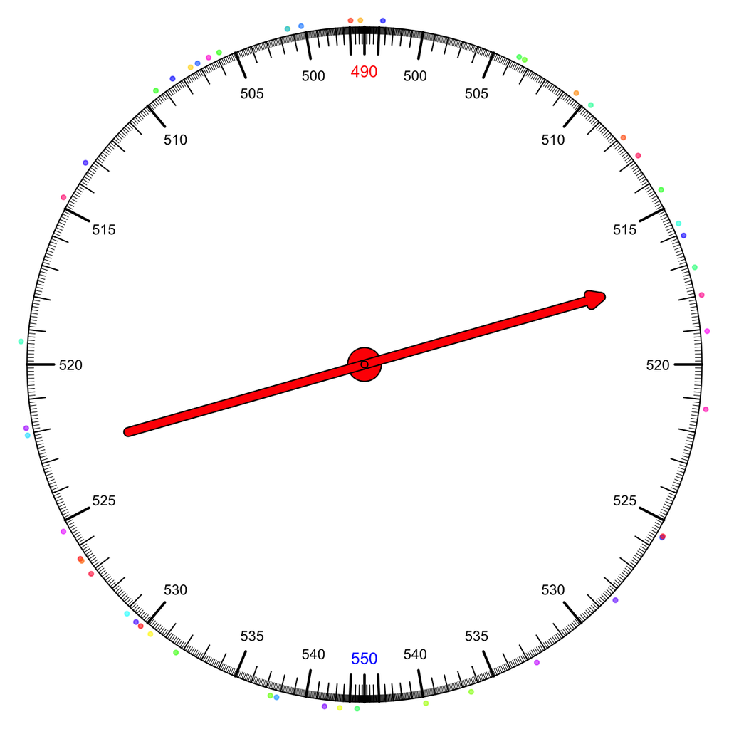

The name "triangular distribution" comes from the probability density curve.

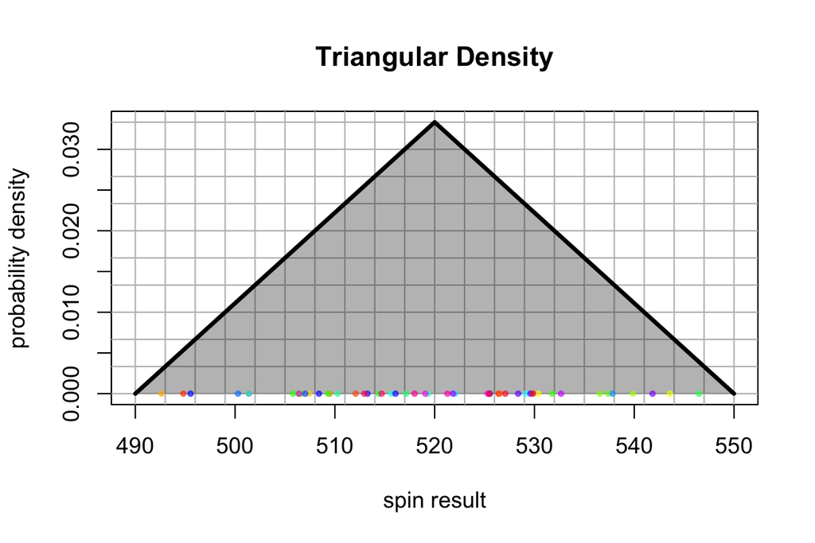

Notice that because the spinner is continuous, it generates data like 518.4353229 and 523.4711215. Of course, a human would probably round to the nearest tenth or so.

### Actual question

The 50 spins were used to generate a histogram.

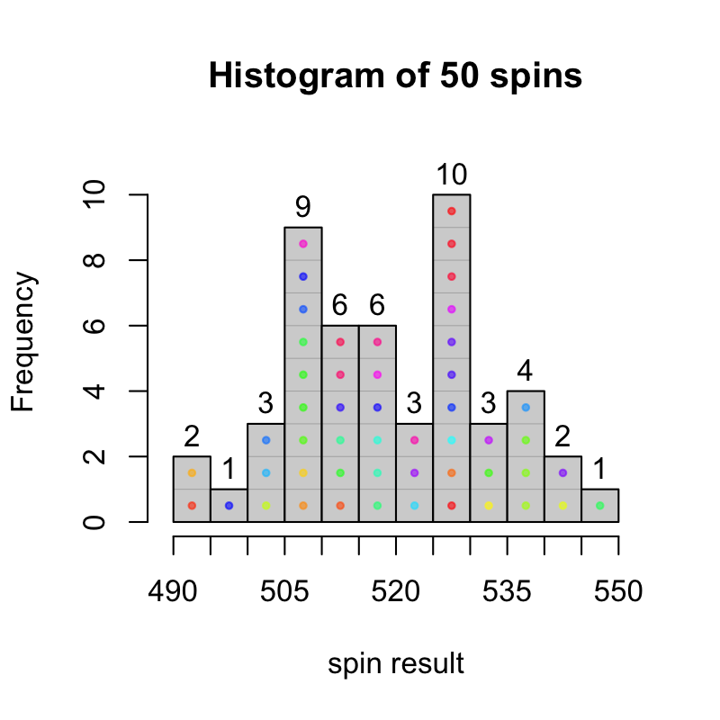

- How many spins were less than 525?
  - $\#(x<525) =$
- What proportion of spins were less than 525?
  - $\mathrm{proportion}(x<525) =$
- How many spins were more than 510?
  - $\#(x>510) =$
- What proportion of spins were more than 510?
  - $\mathrm{proportion}(x>510) =$
- How many spins were between 495 and 520?
  - $\#(495<x<520) =$
- What proportion of spins were between 495 and 520?
  - $\mathrm{proportion}(495<x<520) =$
- $\#(x<525) =$ 30
- $\mathrm{proportion}(x<525) = \frac{30}{50} =$ 0.6
- $\#(x>510) =$ 35
- $\mathrm{proportion}(x>510) = \frac{35}{50} =$ 0.7
- $\#(495<x<520) =$ 25
- $\mathrm{proportion}(495<x<520) = \frac{25}{50} =$ 0.5

You might find the following visualizations helpful.

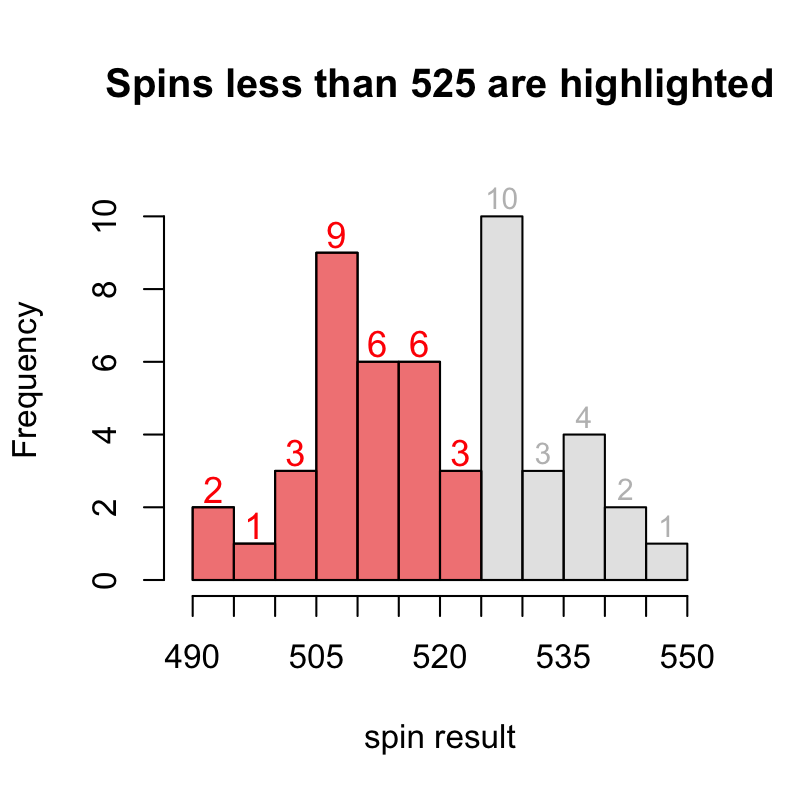

$$2+1+3+9+6+6+3=30$$

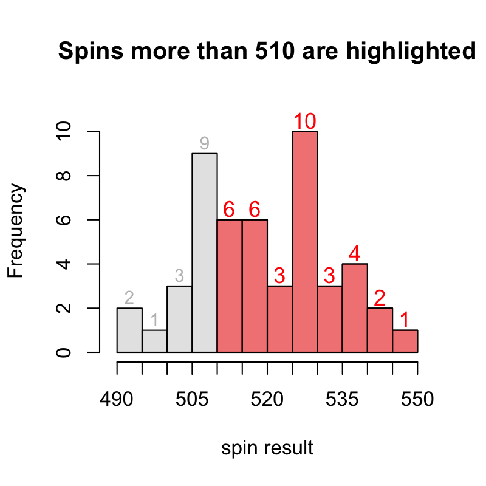

$$6+6+3+10+3+4+2+1=35$$

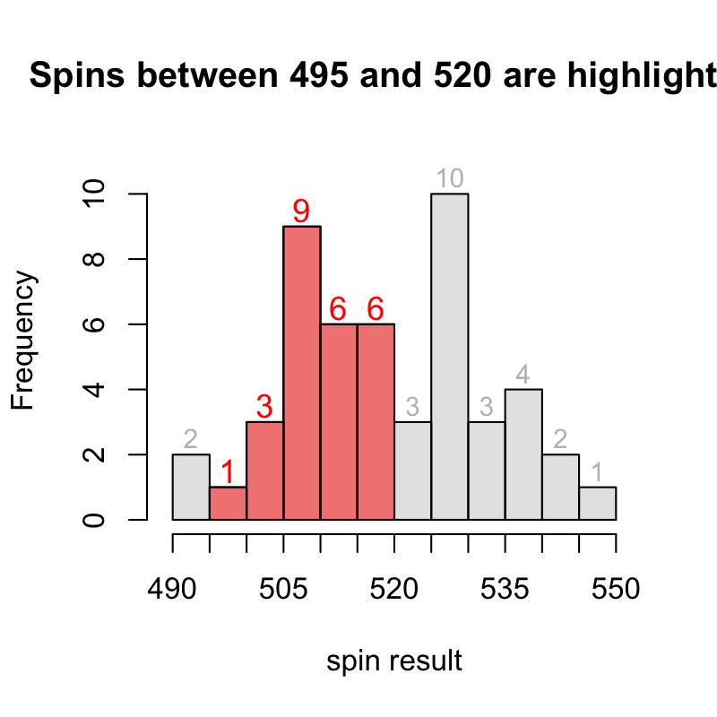

$$1+3+9+6+6=25$$

*S-ID.A: Summarize, represent, and interpret data on a single count or measurement variable. Use calculators, spreadsheets, and other technology as appropriate.*

A spinner was made to model a [continuous triangular distribution](https://en.wikipedia.org/wiki/Triangular_distribution). It was spun 50 times; those locations are marked.

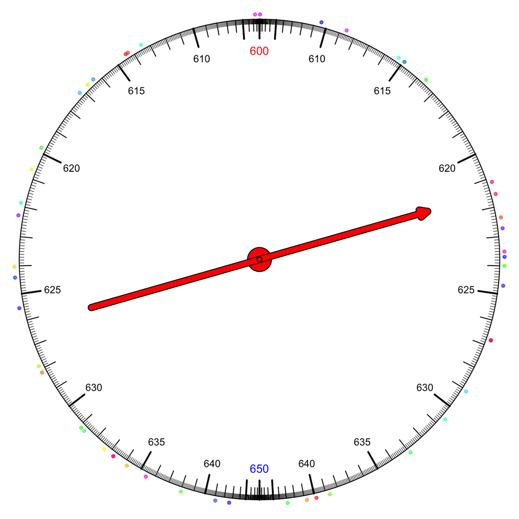

The name "triangular distribution" comes from the probability density curve.

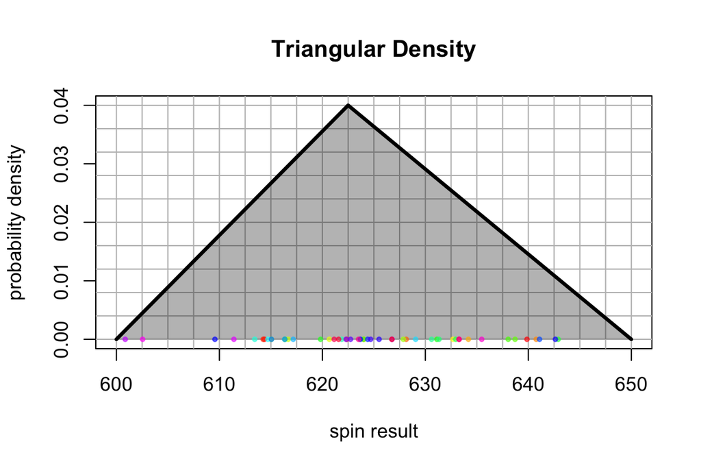

Notice that because the spinner is continuous, it generates data like 612.8696373 and 618.7734489. Of course, a human would probably round to the nearest tenth or so.

### Actual question

The 50 spins were used to generate a histogram.

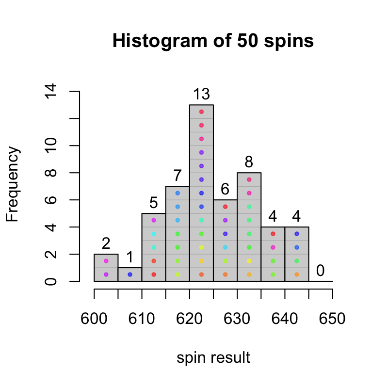

- How many spins were less than 615?
  - $\#(x<615) =$
- What proportion of spins were less than 615?
  - $\mathrm{proportion}(x<615) =$
- How many spins were more than 630?
  - $\#(x>630) =$
- What proportion of spins were more than 630?
  - $\mathrm{proportion}(x>630) =$
- How many spins were between 620 and 635?
  - $\#(620<x<635) =$
- What proportion of spins were between 620 and 635?
  - $\mathrm{proportion}(620<x<635) =$
- $\#(x<615) =$ 8
- $\mathrm{proportion}(x<615) = \frac{8}{50} =$ 0.16
- $\#(x>630) =$ 16
- $\mathrm{proportion}(x>630) = \frac{16}{50} =$ 0.32
- $\#(620<x<635) =$ 27
- $\mathrm{proportion}(620<x<635) = \frac{27}{50} =$ 0.54

You might find the following visualizations helpful.

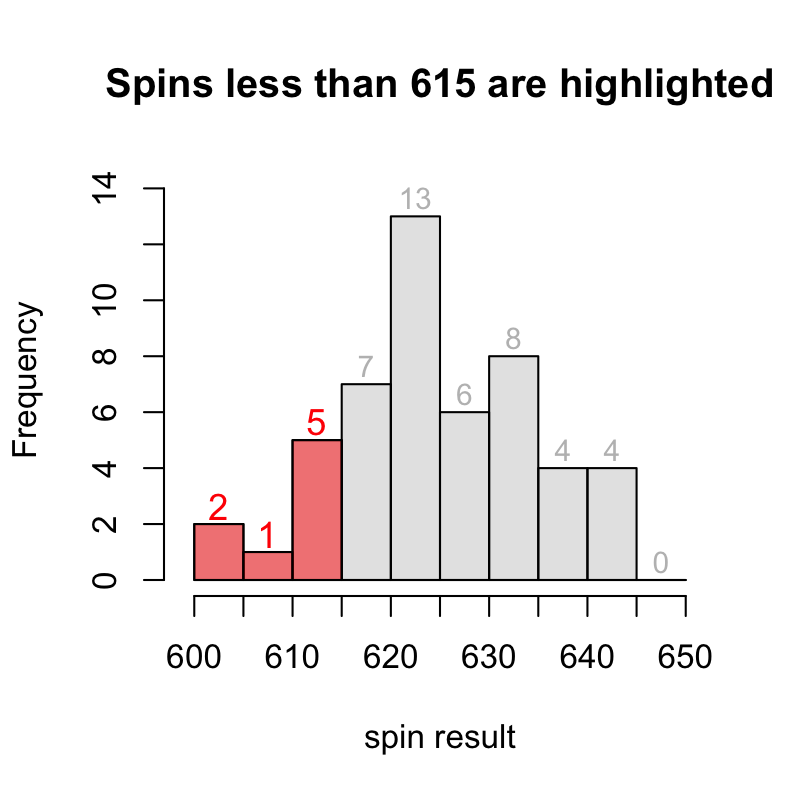

$$2+1+5=8$$

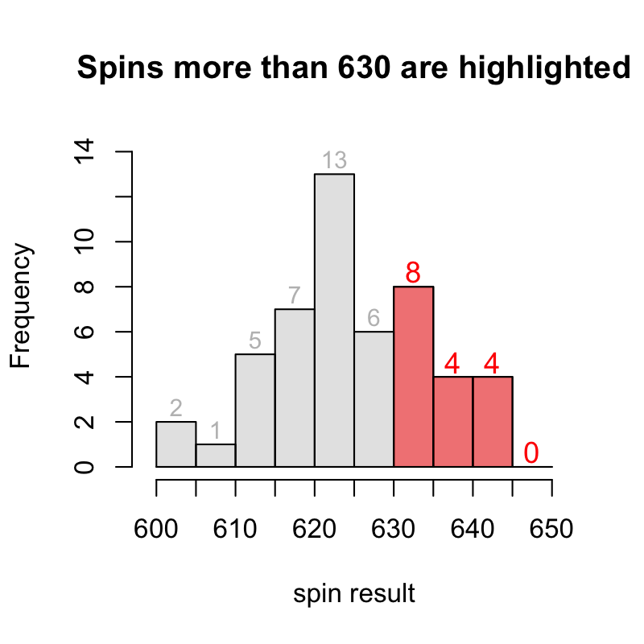

$$8+4+4+0=16$$

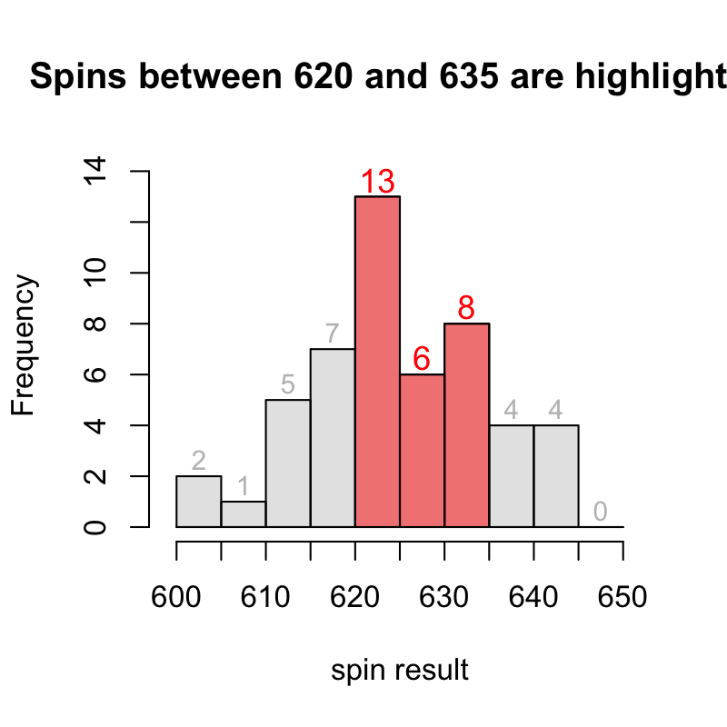

$$13+6+8=27$$

*S-ID.A: Summarize, represent, and interpret data on a single count or measurement variable. Use calculators, spreadsheets, and other technology as appropriate.*

A spinner was made to model a [continuous triangular distribution](https://en.wikipedia.org/wiki/Triangular_distribution). It was spun 50 times; those locations are marked.

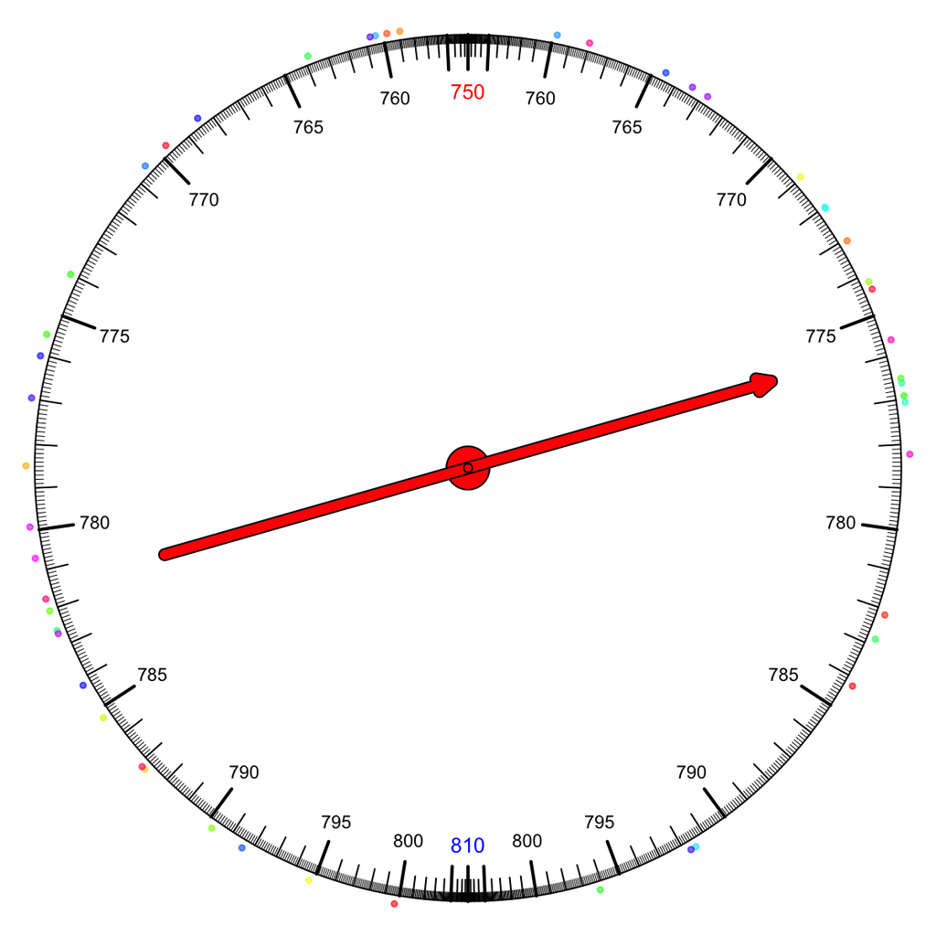

The name "triangular distribution" comes from the probability density curve.

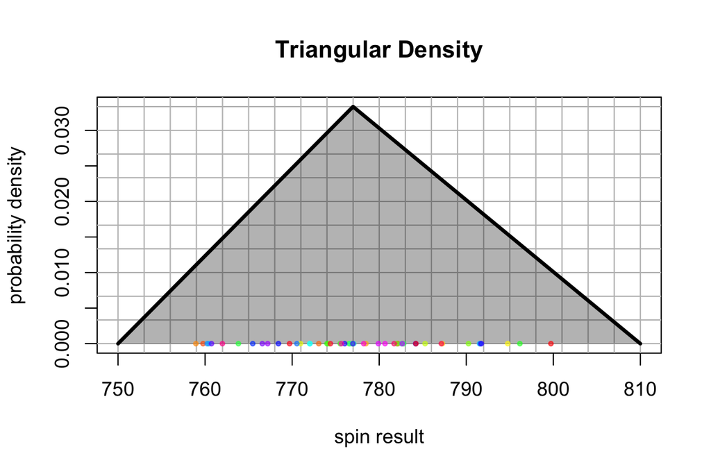

Notice that because the spinner is continuous, it generates data like 789.6077438 and 788.2769197. Of course, a human would probably round to the nearest tenth or so.

### Actual question

The 50 spins were used to generate a histogram.

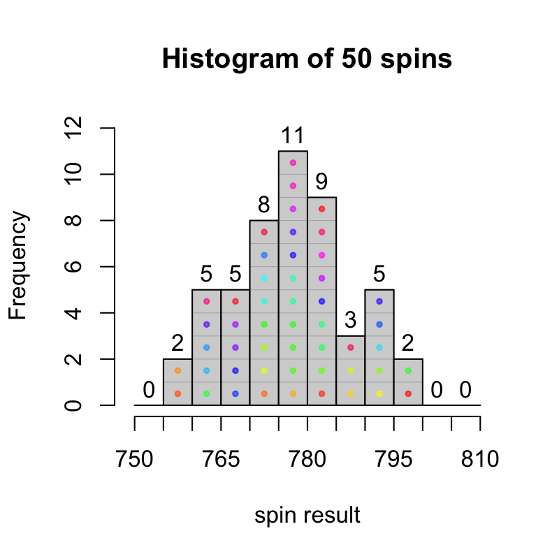

- How many spins were less than 780?
  - $\#(x<780) =$
- What proportion of spins were less than 780?
  - $\mathrm{proportion}(x<780) =$
- How many spins were more than 790?
  - $\#(x>790) =$
- What proportion of spins were more than 790?
  - $\mathrm{proportion}(x>790) =$
- How many spins were between 770 and 805?
  - $\#(770<x<805) =$
- What proportion of spins were between 770 and 805?
  - $\mathrm{proportion}(770<x<805) =$
- $\#(x<780) =$ 31
- $\mathrm{proportion}(x<780) = \frac{31}{50} =$ 0.62
- $\#(x>790) =$ 7
- $\mathrm{proportion}(x>790) = \frac{7}{50} =$ 0.14
- $\#(770<x<805) =$ 38
- $\mathrm{proportion}(770<x<805) = \frac{38}{50} =$ 0.76

You might find the following visualizations helpful.

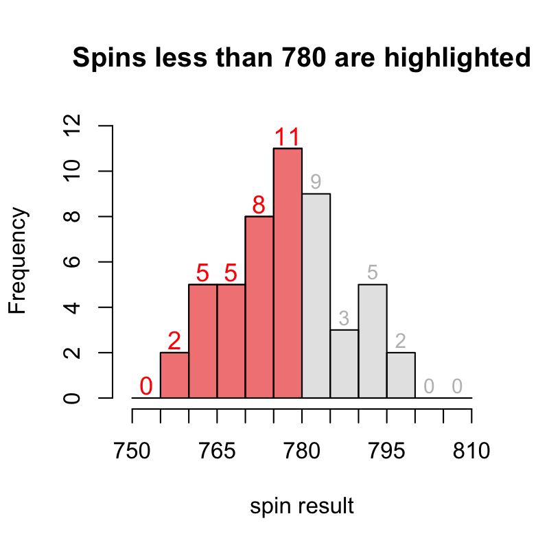

$$0+2+5+5+8+11=31$$

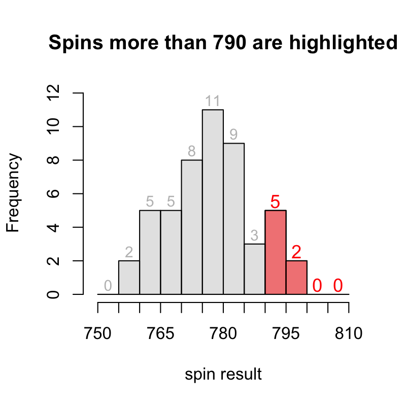

$$5+2+0+0=7$$

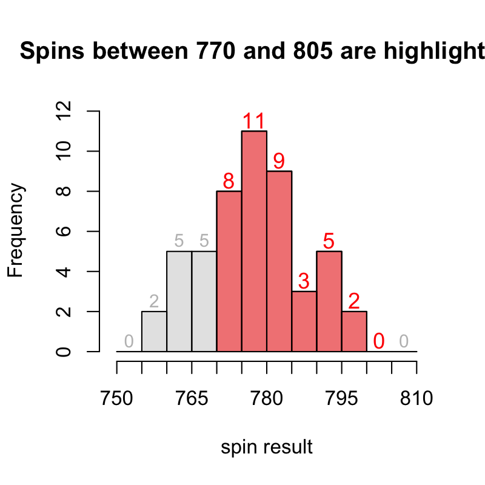

$$8+11+9+3+5+2+0=38$$

*S-ID.A: Summarize, represent, and interpret data on a single count or measurement variable. Use calculators, spreadsheets, and other technology as appropriate.*

A spinner was made to model a [continuous triangular distribution](https://en.wikipedia.org/wiki/Triangular_distribution). It was spun 50 times; those locations are marked.

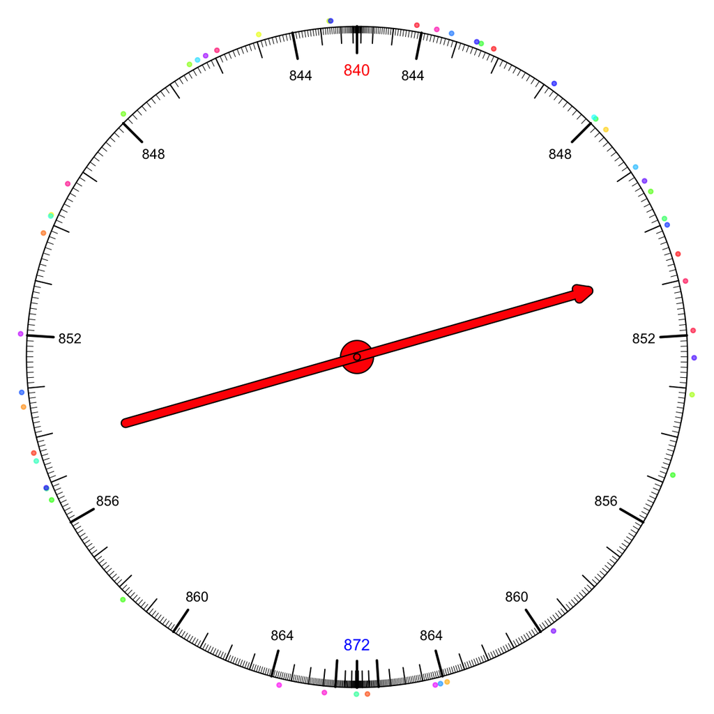

The name "triangular distribution" comes from the probability density curve.

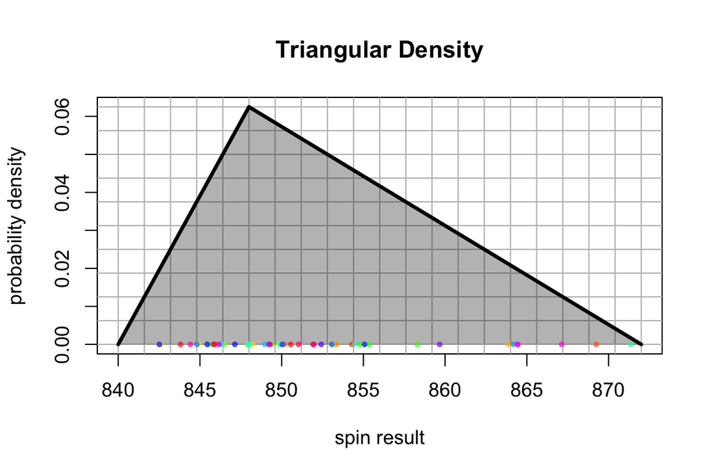

Notice that because the spinner is continuous, it generates data like 848.1978092 and 854.1566486. Of course, a human would probably round to the nearest tenth or so.

### Actual question

The 50 spins were used to generate a histogram.

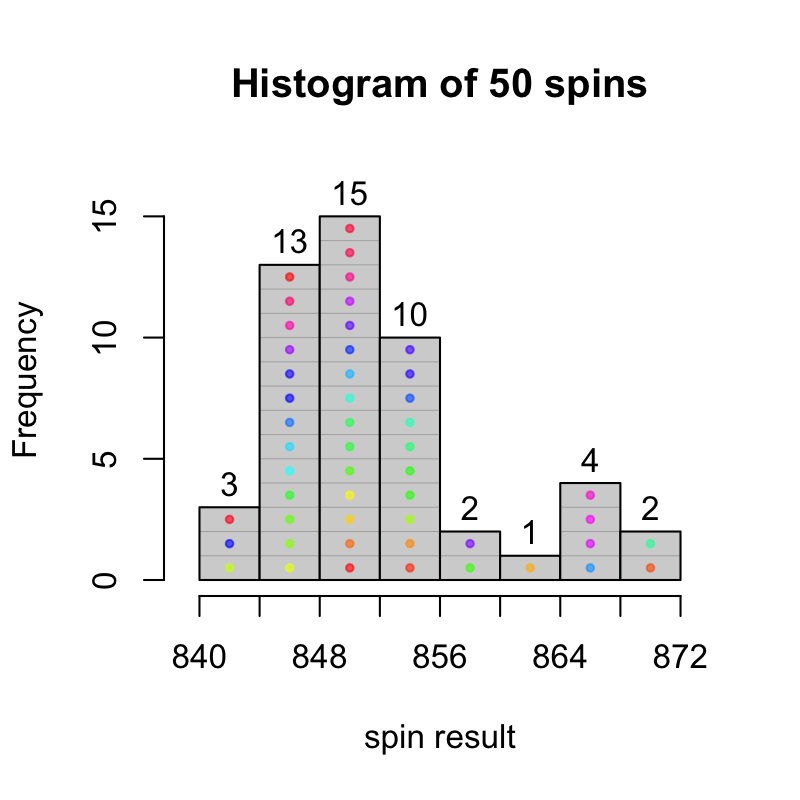

- How many spins were less than 852?
  - $\#(x<852) =$
- What proportion of spins were less than 852?
  - $\mathrm{proportion}(x<852) =$
- How many spins were more than 860?
  - $\#(x>860) =$
- What proportion of spins were more than 860?
  - $\mathrm{proportion}(x>860) =$
- How many spins were between 848 and 868?
  - $\#(848<x<868) =$
- What proportion of spins were between 848 and 868?
  - $\mathrm{proportion}(848<x<868) =$
- $\#(x<852) =$ 31
- $\mathrm{proportion}(x<852) = \frac{31}{50} =$ 0.62
- $\#(x>860) =$ 7
- $\mathrm{proportion}(x>860) = \frac{7}{50} =$ 0.14
- $\#(848<x<868) =$ 32
- $\mathrm{proportion}(848<x<868) = \frac{32}{50} =$ 0.64

You might find the following visualizations helpful.

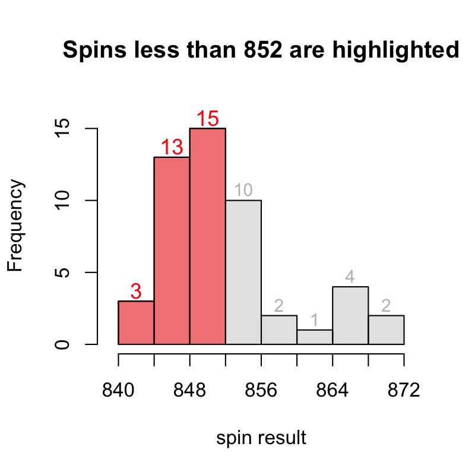

$$3+13+15=31$$

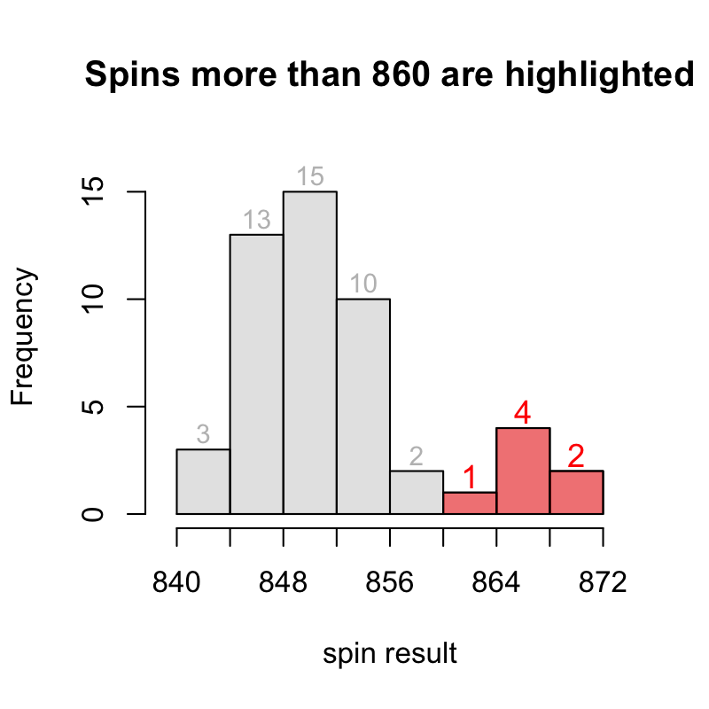

$$1+4+2=7$$

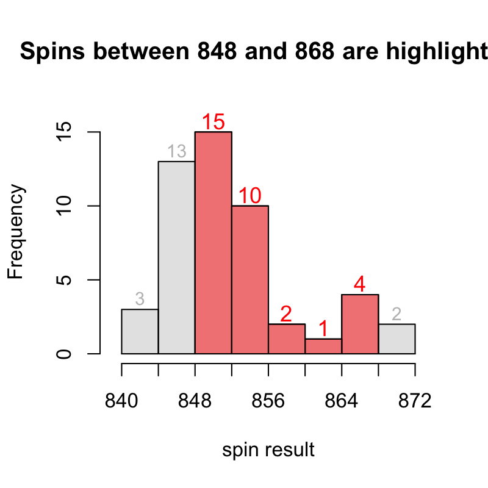

$$15+10+2+1+4=32$$

*S-ID.A: Summarize, represent, and interpret data on a single count or measurement variable. Use calculators, spreadsheets, and other technology as appropriate.*

A spinner was made to model a [continuous triangular distribution](https://en.wikipedia.org/wiki/Triangular_distribution). It was spun 50 times; those locations are marked.

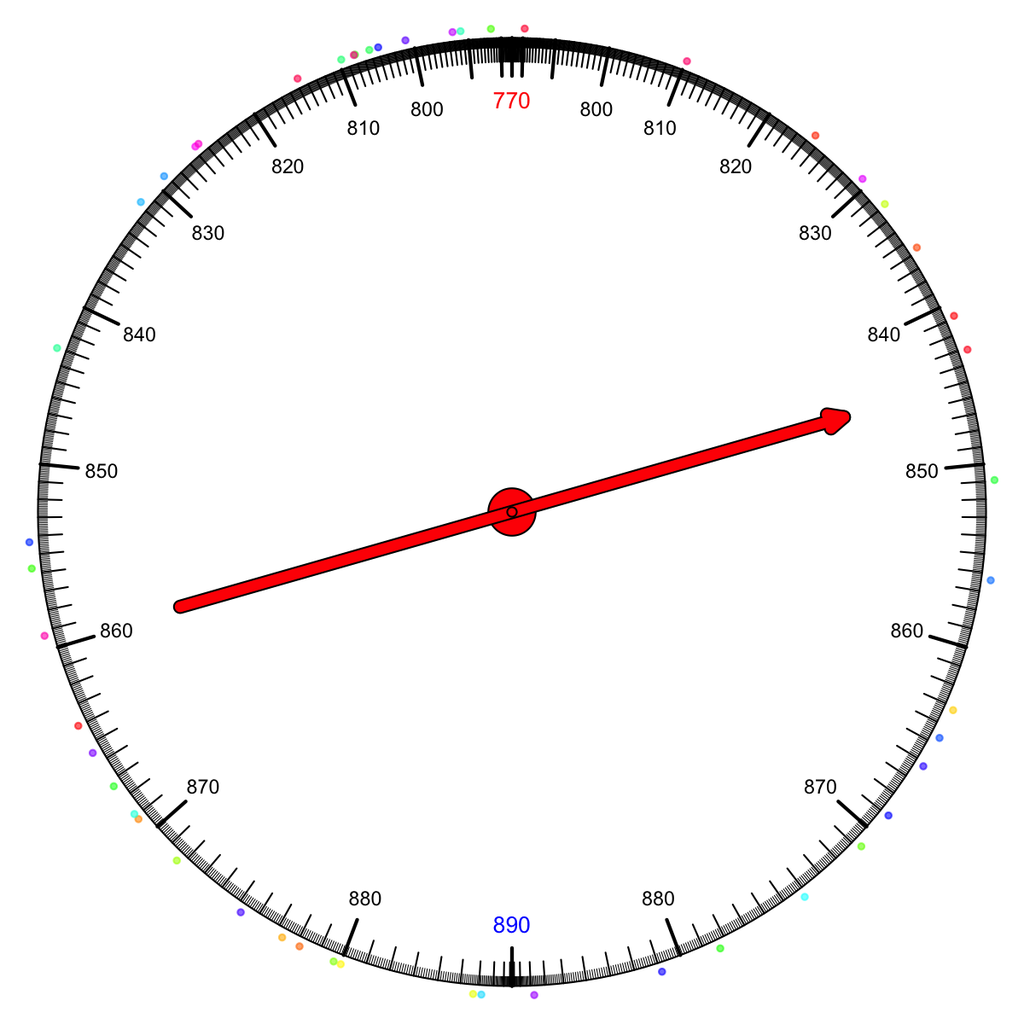

The name "triangular distribution" comes from the probability density curve.

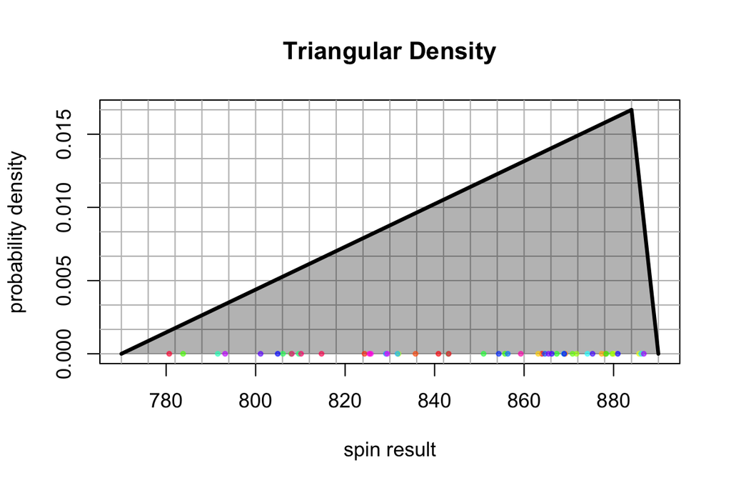

Notice that because the spinner is continuous, it generates data like 870.4324514 and 850.2332399. Of course, a human would probably round to the nearest tenth or so.

### Actual question

The 50 spins were used to generate a histogram.

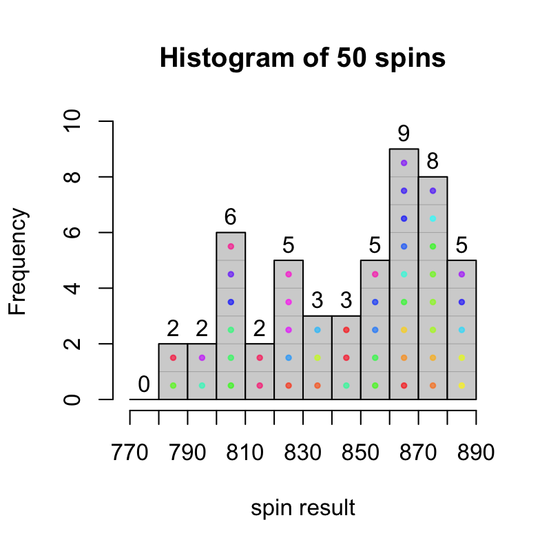

- How many spins were less than 820?
  - $\#(x<820) =$
- What proportion of spins were less than 820?
  - $\mathrm{proportion}(x<820) =$
- How many spins were more than 830?
  - $\#(x>830) =$
- What proportion of spins were more than 830?
  - $\mathrm{proportion}(x>830) =$
- How many spins were between 780 and 840?
  - $\#(780<x<840) =$
- What proportion of spins were between 780 and 840?
  - $\mathrm{proportion}(780<x<840) =$
- $\#(x<820) =$ 12
- $\mathrm{proportion}(x<820) = \frac{12}{50} =$ 0.24
- $\#(x>830) =$ 33
- $\mathrm{proportion}(x>830) = \frac{33}{50} =$ 0.66
- $\#(780<x<840) =$ 20
- $\mathrm{proportion}(780<x<840) = \frac{20}{50} =$ 0.4

You might find the following visualizations helpful.

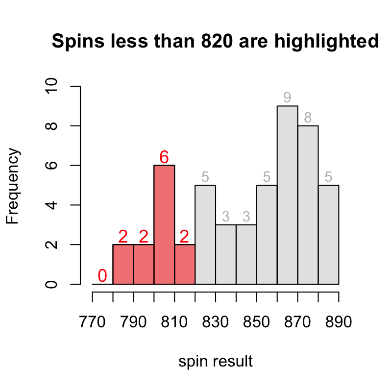

$$0+2+2+6+2=12$$

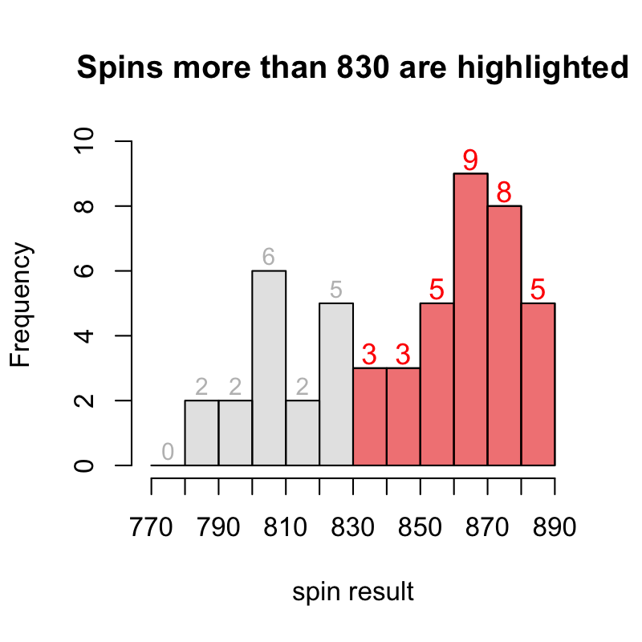

$$3+3+5+9+8+5=33$$

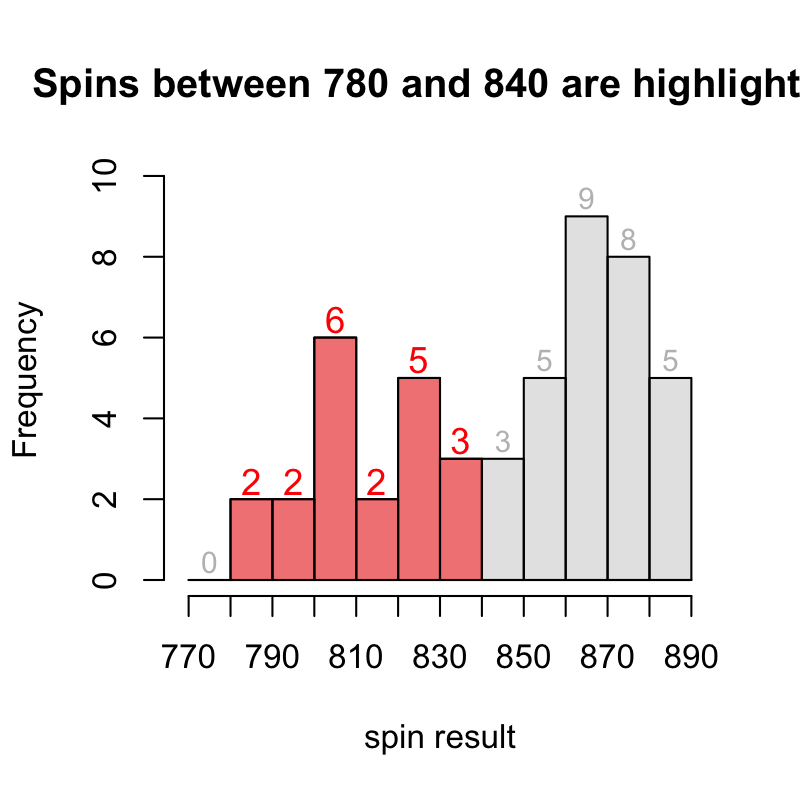

$$2+2+6+2+5+3=20$$

*S-ID.A: Summarize, represent, and interpret data on a single count or measurement variable. Use calculators, spreadsheets, and other technology as appropriate.*

A spinner was made to model a [continuous triangular distribution](https://en.wikipedia.org/wiki/Triangular_distribution). It was spun 50 times; those locations are marked.

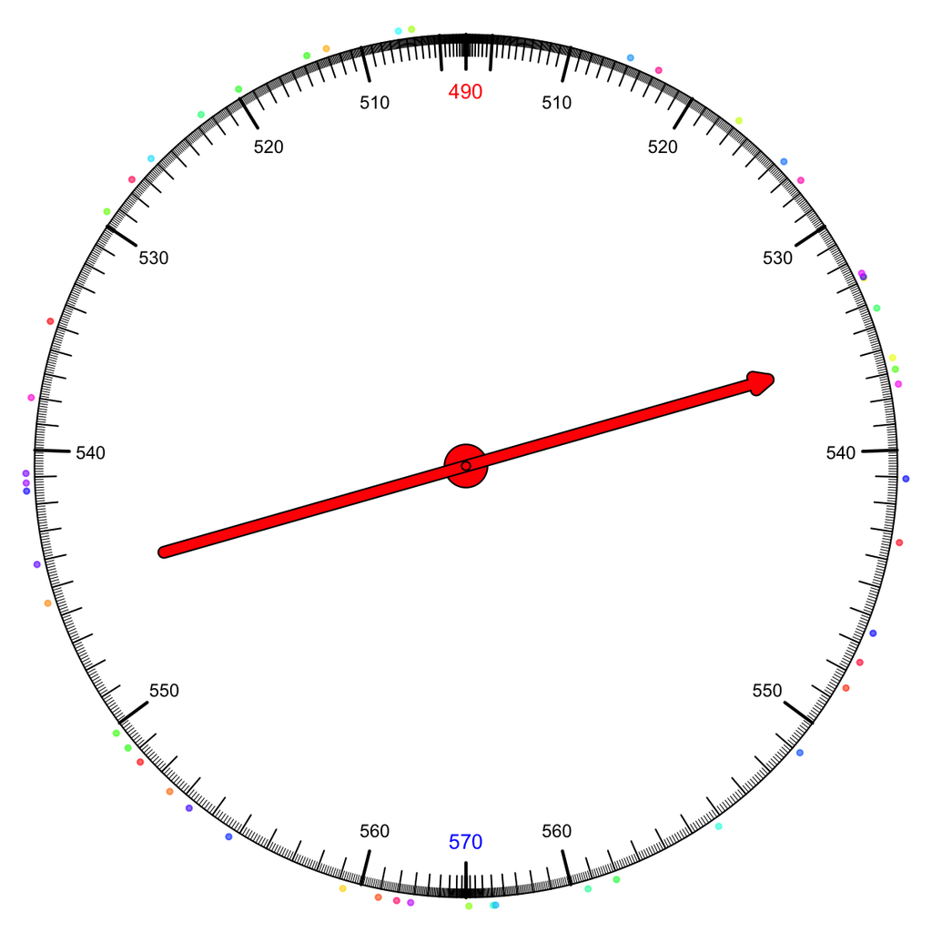

The name "triangular distribution" comes from the probability density curve.

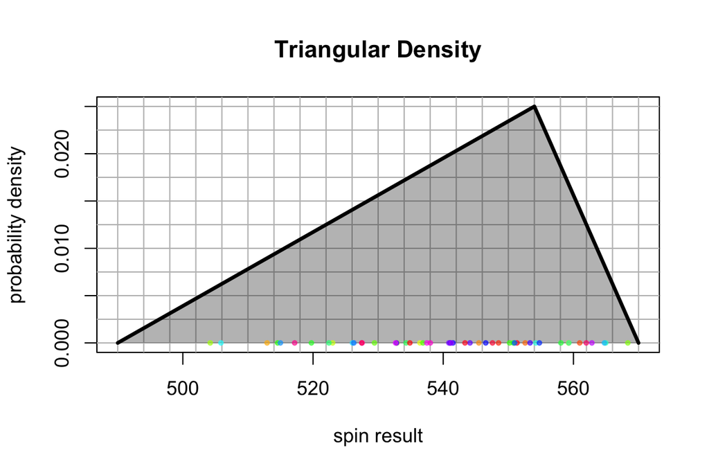

Notice that because the spinner is continuous, it generates data like 555.2618672 and 550.5218529. Of course, a human would probably round to the nearest tenth or so.